# EDA

Research paper here: http://www.math-evry.cnrs.fr/_media/members/aguilloux/enseignements/m1mint/moro2016.pdf

Dataset here: https://archive-beta.ics.uci.edu/ml/datasets/facebook+metrics

## Imports

```r
library(dplyr)
library(tidyverse)
library(ggplot2)
library(grid)
library(gridExtra)
library(sandwich) # need to install
library(lmtest)   # need to install
library(stargazer)
```

## Read data

```r
# read data as is
fb_data = read_delim("./dataset_Facebook.csv", delim=";")
# change col names
cols = c(
  "page_ttl_likes",
  "type",
  "category",
  "post_month",
  "post_wkday",
  "post_hour",
  "paid",
  "lifetime_post_reach",
  "lifetime_post_impressions",
  "lifetime_engaged_users",
  "lifetime_post_consumers",
  "lifetime_post_consumptions",
  "lifetime_post_impressions_from_page_have_likeds",
  "lifetime_post_impressions_from_page_likes",
  "lifetime_people_liked_engaged_with_post",
  "comments",
  "likes",
  "shares",
  "interactions"
)
colnames(fb_data) = cols

fb_data = fb_data %>%
  mutate(
    day_period=case_when(
      post_hour >= 1  & post_hour <= 5  ~ "overnight",
      post_hour >= 6  & post_hour <= 11 ~ "morning",
      post_hour >= 12 & post_hour <= 17 ~ "afternoon",
      post_hour >= 18 & post_hour <= 23 ~ "evening"
    )
  )

fb_data = fb_data %>%
  mutate(
    media_type=case_when(
      type == "Video" ~ "media",
      type == "Photo" ~ "media",
      TRUE            ~ "non-media"
    )
  )

summary(fb_data)
```

```
##  page_ttl_likes       type              category      post_month
##  Min.   : 81370   Length:500         Min.   :1.00   Min.   : 1.000
##  1st Qu.:112676   Class :character   1st Qu.:1.00   1st Qu.: 4.000
##  Median :129600   Mode  :character   Median :2.00   Median : 7.000
##  Mean   :123194                      Mean   :1.88   Mean   : 7.038
##  3rd Qu.:136393                      3rd Qu.:3.00   3rd Qu.:10.000
##  Max.   :139441                      Max.   :3.00   Max.   :12.000
##
##    post_wkday     post_hour          paid        lifetime_post_reach
##  Min.   :1.00   Min.   : 1.00   Min.   :0.0000   Min.   :   238
##  1st Qu.:2.00   1st Qu.: 3.00   1st Qu.:0.0000   1st Qu.:  3315
##  Median :4.00   Median : 9.00   Median :0.0000   Median :  5281
##  Mean   :4.15   Mean   : 7.84   Mean   :0.2786   Mean   : 13903
##  3rd Qu.:6.00   3rd Qu.:11.00   3rd Qu.:1.0000   3rd Qu.: 13168
##  Max.   :7.00   Max.   :23.00   Max.   :1.0000   Max.   :180480
##                                 NA's   :1
##  lifetime_post_impressions lifetime_engaged_users lifetime_post_consumers
##  Min.   :    570           Min.   :    9.0        Min.   :    9.0
##  1st Qu.:   5695           1st Qu.:  393.8        1st Qu.:  332.5
##  Median :   9051           Median :  625.5        Median :  551.5
##  Mean   :  29586           Mean   :  920.3        Mean   :  798.8
##  3rd Qu.:  22086           3rd Qu.: 1062.0        3rd Qu.:  955.5
##  Max.   :1110282           Max.   :11452.0        Max.   :11328.0
##
##  lifetime_post_consumptions lifetime_post_impressions_from_page_have_likeds
##  Min.   :    9.0            Min.   :    567
##  1st Qu.:  509.2            1st Qu.:   3970
##  Median :  851.0            Median :   6256
##  Mean   : 1415.1            Mean   :  16766
##  3rd Qu.: 1463.0            3rd Qu.:  14860
##  Max.   :19779.0            Max.   :1107833
##
##  lifetime_post_impressions_from_page_likes
##  Min.   :  236
##  1st Qu.: 2182
##  Median : 3417
##  Mean   : 6585
##  3rd Qu.: 7989
##  Max.   :51456
##
##  lifetime_people_liked_engaged_with_post    comments           likes
##  Min.   :   9.0                          Min.   :  0.000   Min.   :   0.0
##  1st Qu.: 291.0                          1st Qu.:  1.000   1st Qu.:  56.5
##  Median : 412.0                          Median :  3.000   Median : 101.0
##  Mean   : 610.0                          Mean   :  7.482   Mean   : 177.9
##  3rd Qu.: 656.2                          3rd Qu.:  7.000   3rd Qu.: 187.5
##  Max.   :4376.0                          Max.   :372.000   Max.   :5172.0
##                                                            NA's   :1
##      shares        interactions     day_period         media_type
##  Min.   :  0.00   Min.   :   0.0   Length:500         Length:500
##  1st Qu.: 10.00   1st Qu.:  71.0   Class :character   Class :character
##  Median : 19.00   Median : 123.5   Mode  :character   Mode  :character
##  Mean   : 27.27   Mean   : 212.1
##  3rd Qu.: 32.25   3rd Qu.: 228.5
##  Max.   :790.00   Max.   :6334.0
##  NA's   :4
```

## EDA

### Output variables

#### Engagement

Based on the paper, we can have the post’s engaged users as output. The variable has a strong right skewed distribution, so we could potentially apply a log transformation. This would allow us to normalize the variable, minimize the outliers and interpret the coefficient as changes in the % of the variable, not the absolute values:

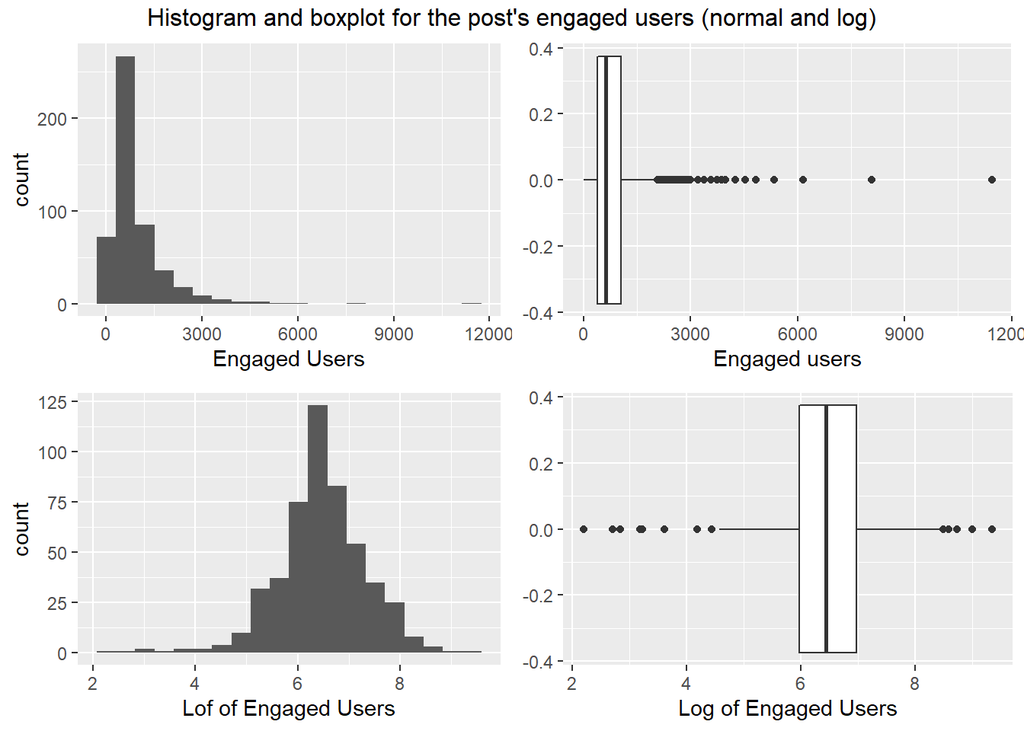

The paper actually runs the analysis by trying to predict 12 different variables using 7 inputs. I’ll add a few other graphs here:

#### Interactions

Interactions is the sum of likes, shares and comments:

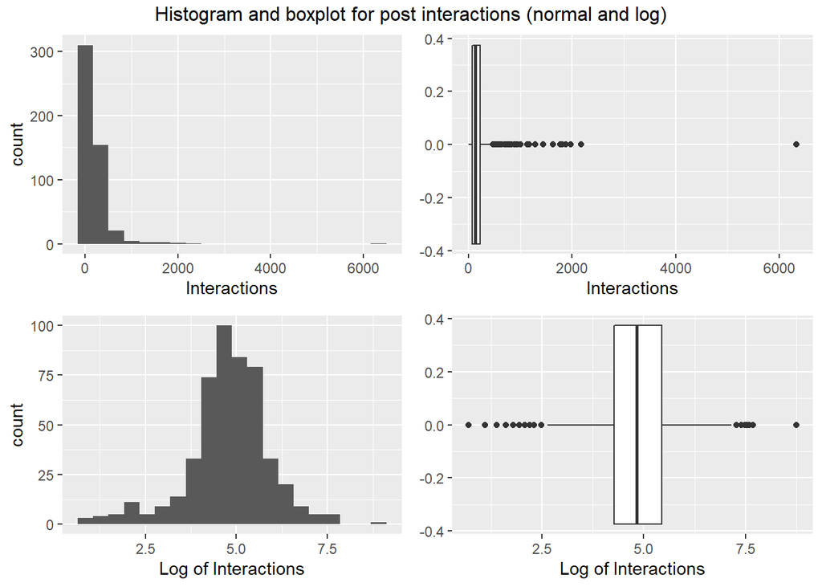

```r
p1 = fb_data %>% ggplot() +
  aes(x=interactions) +
  geom_histogram(bins=20) +
  labs(x="Interactions")

p2 = fb_data %>% ggplot() +
  aes(x=log(interactions)) +
  geom_histogram(bins=20) +
  labs(x="Log of Interactions")

pb = fb_data %>% ggplot() +
  aes(x=interactions) +
  geom_boxplot() +
  labs(x="Interactions")

pb2 = fb_data %>% ggplot() +
  aes(x=log(interactions)) +
  geom_boxplot() +
  labs(x="Log of Interactions")

grid.arrange(p1, pb, p2, pb2, ncol=2, nrow=2, top="Histogram and boxplot for post interactions (normal and log)")
```

#### Reach

Number of people the post reached:

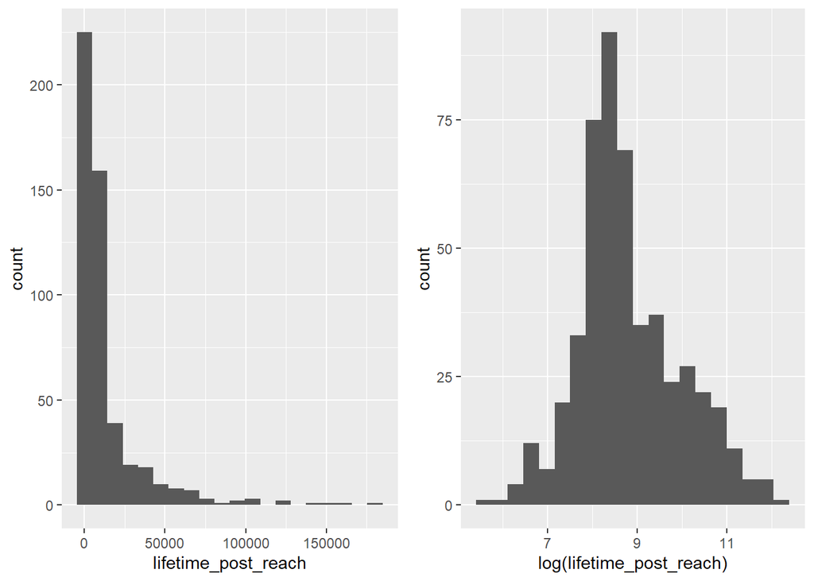

```r
p1 = fb_data %>% ggplot() +
  aes(x=lifetime_post_reach) +
  geom_histogram(bins=20)

p2 = fb_data %>% ggplot() +
  aes(x=log(lifetime_post_reach)) +
  geom_histogram(bins=20)

grid.arrange(p1, p2, ncol=2)
```

#### Comments

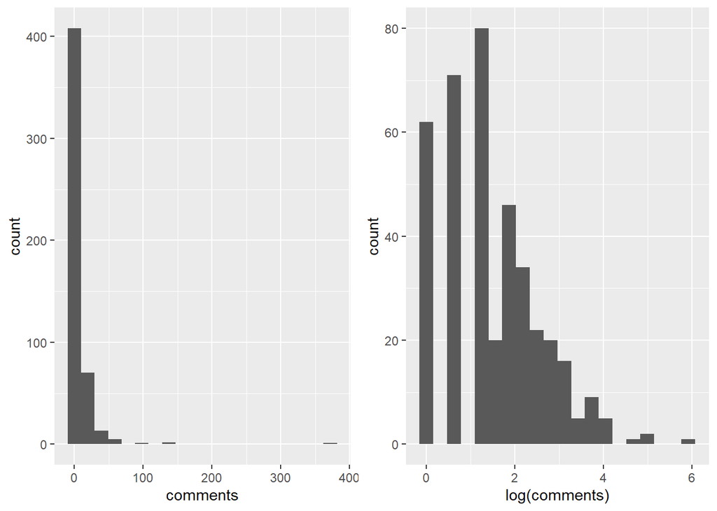

```r
p1 = fb_data %>% ggplot() +
  aes(x=comments) +
  geom_histogram(bins=20)

p2 = fb_data %>% ggplot() +
  aes(x=log(comments)) +
  geom_histogram(bins=20)

grid.arrange(p1, p2, ncol=2)
```

#### Likes

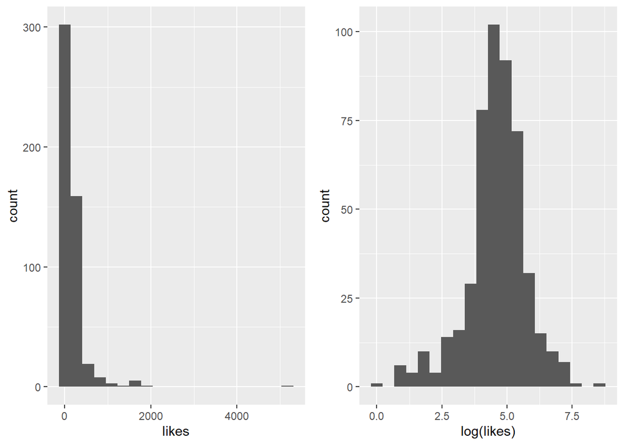

```r
p1 = fb_data %>% ggplot() +
  aes(x=likes) +
  geom_histogram(bins=20)

p2 = fb_data %>% ggplot() +
  aes(x=log(likes)) +
  geom_histogram(bins=20)

grid.arrange(p1, p2, ncol=2)
```

#### Shares

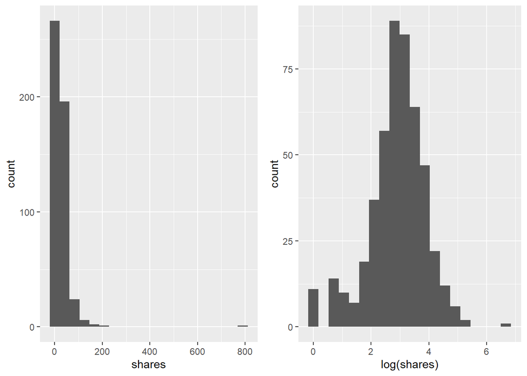

```r
p1 = fb_data %>% ggplot() +
  aes(x=shares) +
  geom_histogram(bins=20)

p2 = fb_data %>% ggplot() +
  aes(x=log(shares)) +
  geom_histogram(bins=20)

grid.arrange(p1, p2, ncol=2)
```

#### Brand Awareness

Tae also proposed using the brand awareness as an output variable, which could be a nice twist to what was done on the paper:

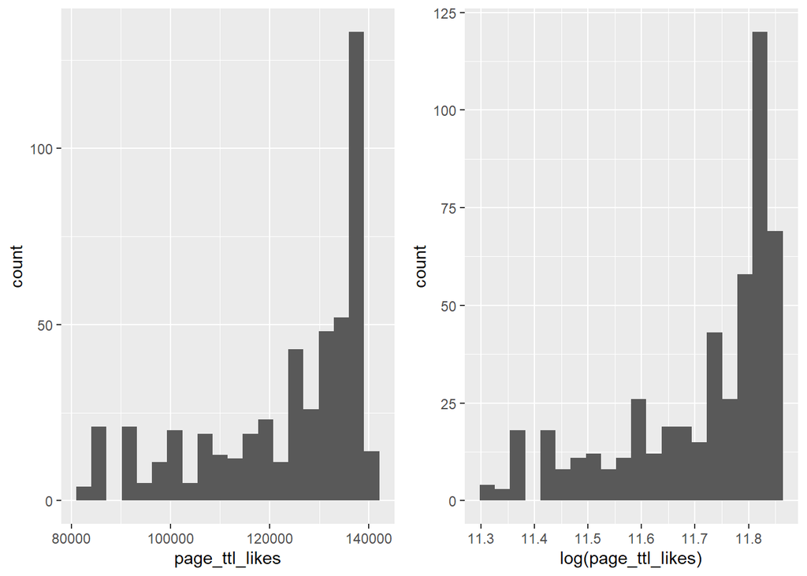

```r
p1 = fb_data %>% ggplot() +
  aes(x=page_ttl_likes) +
  geom_histogram(bins=20)

p2 = fb_data %>% ggplot() +
  aes(x=log(page_ttl_likes)) +
  geom_histogram(bins=20)

grid.arrange(p1, p2, ncol=2)
```

### Explanatory variables

The paper uses 7 variables to try to explain 12 outcome ones (most of them explained above)

#### Brand Awareness

This would be the main variable we would like to understand the impact. It is expressed in the number of likes the FB page of the company had when the post was published:

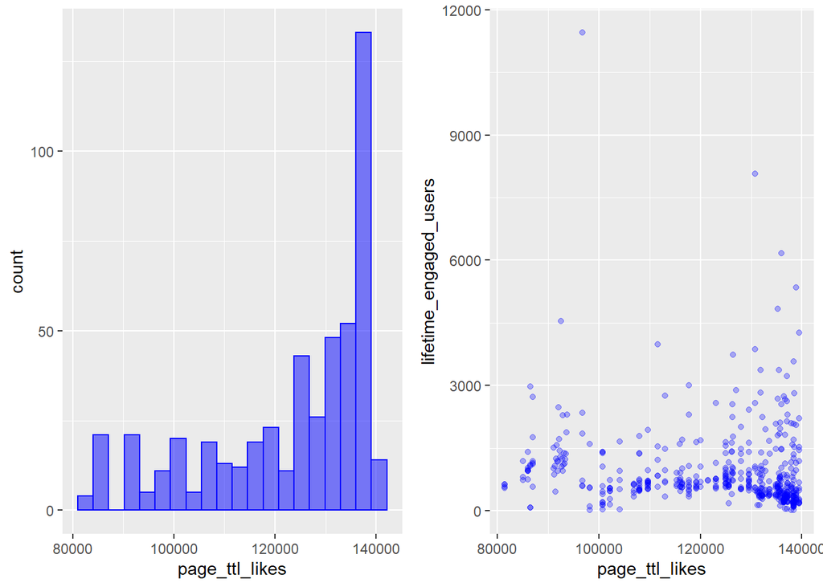

```r
p1 = fb_data %>% ggplot() +
  aes(x=page_ttl_likes) +
  geom_histogram(bins=20, color="blue", fill="blue", alpha=0.5)

p2 = fb_data %>% ggplot() +
  aes(x=page_ttl_likes, y=lifetime_engaged_users) +
  geom_point(alpha=0.3, fill="blue", color="blue")


grid.arrange(p1, p2, ncol=2)
```

Surprisingly, it displays a low negative correlation, although it may be the case that the relationship is not linear:

```r
cor(fb_data$page_ttl_likes, fb_data$lifetime_engaged_users)
```

```
## [1] -0.1119218
```

Running a simple linear regression of this, the coefficient is significant to 5% level (assuming homoscedasticity):

```r
mod = lm(lifetime_engaged_users ~ 1 + page_ttl_likes, data=fb_data)
summary(mod)
```

```
##
## Call:
## lm(formula = lifetime_engaged_users ~ 1 + page_ttl_likes, data = fb_data)
##
## Residuals:
##     Min      1Q  Median      3Q     Max
## -1103.0  -491.9  -297.1   105.5 10352.5
##
## Coefficients:
##                  Estimate Std. Error t value Pr(>|t|)
## (Intercept)     1.755e+03  3.349e+02   5.240 2.38e-07 ***
## page_ttl_likes -6.775e-03  2.695e-03  -2.513   0.0123 *
## ---
## Signif. codes:  0 '***' 0.001 '**' 0.01 '*' 0.05 '.' 0.1 ' ' 1
##
## Residual standard error: 979.8 on 498 degrees of freedom
## Multiple R-squared:  0.01253,    Adjusted R-squared:  0.01054
## F-statistic: 6.317 on 1 and 498 DF,  p-value: 0.01227
```

Heteroscedastic test:

```r
coeftest(mod, vcov=vcovHC(mod, type="HC1"))
```

```
##
## t test of coefficients:
##
##                   Estimate  Std. Error t value  Pr(>|t|)
## (Intercept)     1.7550e+03  3.8314e+02  4.5804 5.871e-06 ***
## page_ttl_likes -6.7748e-03  3.0377e-03 -2.2302   0.02618 *
## ---
## Signif. codes:  0 '***' 0.001 '**' 0.01 '*' 0.05 '.' 0.1 ' ' 1
```

A log-level model the coeff is very signficant:

```r
loglev_mod = lm(I(log(lifetime_engaged_users)) ~ 1 + page_ttl_likes, data=fb_data)
summary(loglev_mod)
```

```
##
## Call:
## lm(formula = I(log(lifetime_engaged_users)) ~ 1 + page_ttl_likes,
##     data = fb_data)
##
## Residuals:
##     Min      1Q  Median      3Q     Max
## -4.5181 -0.4258 -0.0405  0.4513  2.6158
##
## Coefficients:
##                  Estimate Std. Error t value Pr(>|t|)
## (Intercept)     7.720e+00  2.981e-01  25.893  < 2e-16 ***
## page_ttl_likes -1.023e-05  2.399e-06  -4.263 2.41e-05 ***
## ---
## Signif. codes:  0 '***' 0.001 '**' 0.01 '*' 0.05 '.' 0.1 ' ' 1
##
## Residual standard error: 0.8722 on 498 degrees of freedom
## Multiple R-squared:  0.03521,    Adjusted R-squared:  0.03328
## F-statistic: 18.18 on 1 and 498 DF,  p-value: 2.409e-05
```

And the heteroscedastic test:

```r
coeftest(loglev_mod, vcov=vcovHC(loglev_mod, type="HC1"))
```

```
##
## t test of coefficients:
##
##                   Estimate  Std. Error t value  Pr(>|t|)
## (Intercept)     7.7198e+00  3.2446e-01 23.7928 < 2.2e-16 ***
## page_ttl_likes -1.0229e-05  2.6200e-06 -3.9043 0.0001075 ***
## ---
## Signif. codes:  0 '***' 0.001 '**' 0.01 '*' 0.05 '.' 0.1 ' ' 1
```

Same with the log-log model. This may be better as it is easier to interpret:

```r
loglog_mod = lm(I(log(lifetime_engaged_users)) ~ 1 + I(log(page_ttl_likes)), data=fb_data)
summary(loglog_mod)
```

```
##
## Call:
## lm(formula = I(log(lifetime_engaged_users)) ~ 1 + I(log(page_ttl_likes)),
##     data = fb_data)
##
## Residuals:
##     Min      1Q  Median      3Q     Max
## -4.5057 -0.4323 -0.0300  0.4528  2.6264
##
## Coefficients:
##                        Estimate Std. Error t value Pr(>|t|)
## (Intercept)             19.5853     3.1902   6.139 1.70e-09 ***
## I(log(page_ttl_likes))  -1.1207     0.2724  -4.115 4.54e-05 ***
## ---
## Signif. codes:  0 '***' 0.001 '**' 0.01 '*' 0.05 '.' 0.1 ' ' 1
##
## Residual standard error: 0.8732 on 498 degrees of freedom
## Multiple R-squared:  0.03288,    Adjusted R-squared:  0.03094
## F-statistic: 16.93 on 1 and 498 DF,  p-value: 4.537e-05
```

And the hetesk test:

```r
coeftest(loglog_mod, vcov=vcovHC(loglog_mod, type="HC1"))
```

```
##
## t test of coefficients:
##
##                        Estimate Std. Error t value  Pr(>|t|)
## (Intercept)            19.58527    3.44707  5.6817 2.271e-08 ***
## I(log(page_ttl_likes)) -1.12072    0.29433 -3.8077 0.0001578 ***
## ---
## Signif. codes:  0 '***' 0.001 '**' 0.01 '*' 0.05 '.' 0.1 ' ' 1
```

#### Category

This is the category of the post, related to the kind of content it has. Coded in 3 values:

1. Action: Special offers and contests
2. Inspiration: Direct advertisement, explicit brand content
3. Inspiration: Non-explicit brand related content

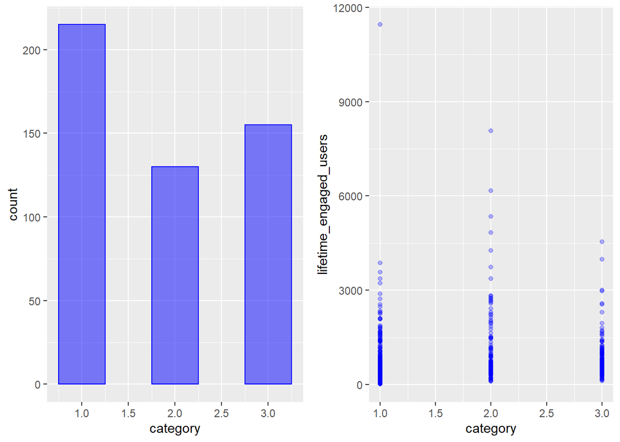

```r
p1 = fb_data %>% ggplot() +
  aes(x=category) +
  geom_bar(width=0.5, alpha=0.5, fill="blue", color="blue")

p2 = fb_data %>% ggplot() +
  aes(x=category, y=lifetime_engaged_users) +
  geom_point(alpha=0.3, fill="blue", color="blue")


grid.arrange(p1, p2, ncol=2)
```

It has a very low correlation:

```r
cor(x=fb_data$category, y=fb_data$lifetime_engaged_users)
```

```
## [1] 0.003392049
```

#### Type

This is the type of the post, either Link, Photo, Status or Video. People mostly post photos:

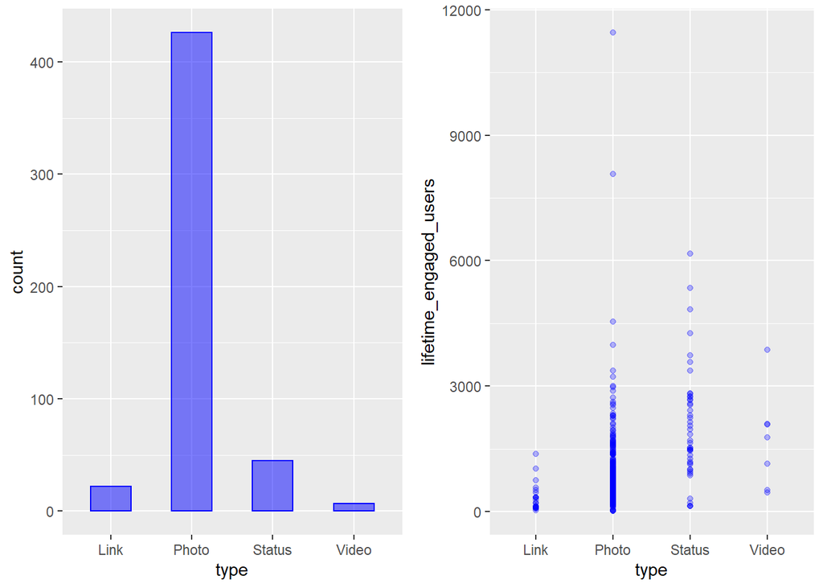

```r
p1 = fb_data %>% ggplot() +
  aes(x=type) +
  geom_bar(width=0.5, alpha=0.5, fill="blue", color="blue")

p2 = fb_data %>% ggplot() +
  aes(x=type, y=lifetime_engaged_users) +
  geom_point(alpha=0.3, fill="blue", color="blue")

grid.arrange(p1, p2, ncol=2)
```

#### Month

Month when the post was published (1-12). The company mostly posted in October:

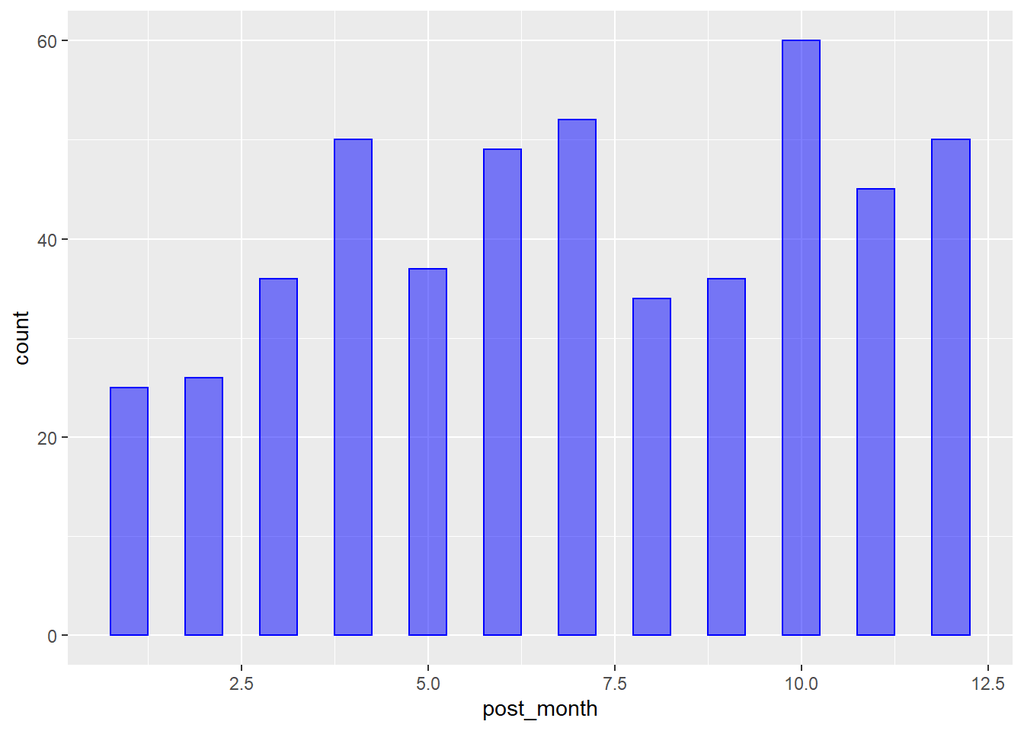

```r
fb_data %>% ggplot() +
  aes(x=post_month) +
  geom_bar(width=0.5, alpha=0.5, fill="blue", color="blue")
```

#### Day of week

Day of the week when the post was published (1-7, 1=Sunday). The company posted mostly during Fri and Sat:

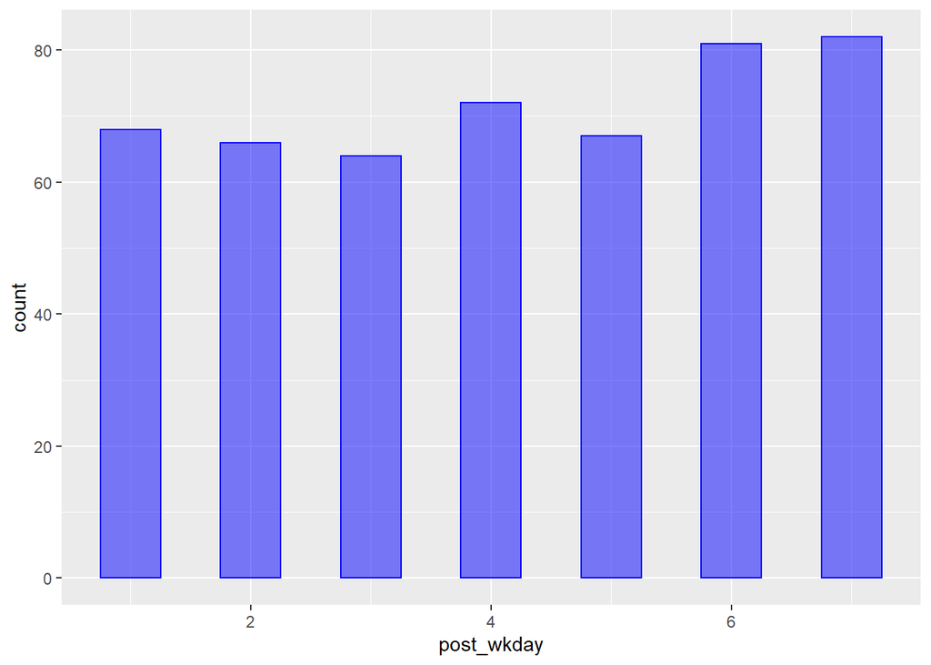

```r
fb_data %>% ggplot() +
  aes(x=post_wkday) +
  geom_bar(width=0.5, alpha=0.5, fill="blue", color="blue")
```

#### Post hour

The hour of the day the post was published (1-24). Compay posted mostly at 3am and 10am:

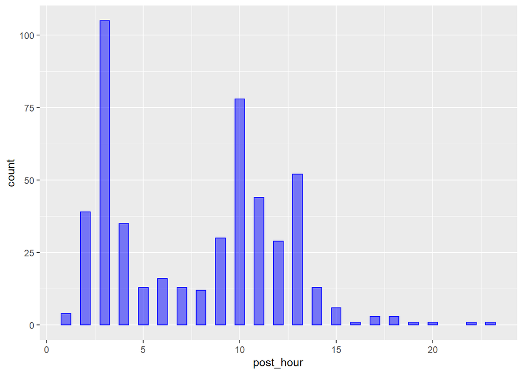

```r
fb_data %>% ggplot() +
  aes(x=post_hour) +
  geom_bar(width=0.5, alpha=0.5, fill="blue", color="blue")
```

## Models

Before fitting the models, we need to remove NA’s, as those bring issues down the line. The only variable with NA’s we will include in the model is `paid`:

```r
fb_data_mod = fb_data %>%
  filter(!is.na(paid))
```

### Basic model

First we will try the basic model:

```r
model1 = lm(I(log(lifetime_engaged_users)) ~ 1 + day_period, data=fb_data_mod)
summary(model1, vcov=vcovHC(model1, type="HC1"))
```

```
##
## Call:
## lm(formula = I(log(lifetime_engaged_users)) ~ 1 + day_period,
##     data = fb_data_mod)
##
## Residuals:
##     Min      1Q  Median      3Q     Max
## -4.2648 -0.4777 -0.0307  0.5334  2.8839
##
## Coefficients:
##                     Estimate Std. Error t value Pr(>|t|)
## (Intercept)          6.67855    0.08641  77.286  < 2e-16 ***
## day_periodevening   -0.60801    0.34411  -1.767  0.07786 .
## day_periodmorning   -0.32455    0.10720  -3.028  0.00259 **
## day_periodovernight -0.21654    0.10700  -2.024  0.04354 *
## ---
## Signif. codes:  0 '***' 0.001 '**' 0.01 '*' 0.05 '.' 0.1 ' ' 1
##
## Residual standard error: 0.8813 on 495 degrees of freedom
## Multiple R-squared:  0.02088,    Adjusted R-squared:  0.01495
## F-statistic: 3.519 on 3 and 495 DF,  p-value: 0.01506
```

The evening period is only significant to the 0.1 level. We’ll see the signficance with robust SEs:

```r
coeftest(model1, vcov=vcovHC(model1, type="HC1"))
```

```
##
## t test of coefficients:
##
##                      Estimate Std. Error t value  Pr(>|t|)
## (Intercept)          6.678552   0.074349 89.8274 < 2.2e-16 ***
## day_periodevening   -0.608013   0.303938 -2.0004  0.045997 *
## day_periodmorning   -0.324549   0.100023 -3.2447  0.001255 **
## day_periodovernight -0.216545   0.098231 -2.2044  0.027952 *
## ---
## Signif. codes:  0 '***' 0.001 '**' 0.01 '*' 0.05 '.' 0.1 ' ' 1
```

The coefficients are now all signficant to the 0.05 level.

#### Assumptions

Because we have more than 100 observations, we can apply the Large-Sample assumptions that are mainly 2: - IID: This requisite is never completely satisfied, and this dataset is not the exception. The interactions of post in the past may affect newer posts for example. For the purposes of this analysis though, and following the analysis of Moro et al., we will assume that doesn’t impede proceeding further with the study. - BLP exists: The main requirement for this is that no perfect collinearity exists. R hasn’t dropped any variables from the model or failed to run the regression, which is a sign that perfect collinearity doesn’t exit.

Even though we only need those, we could check the other CLM requirements:

```
- Normal errors: Errors seem to be left skewed.
```

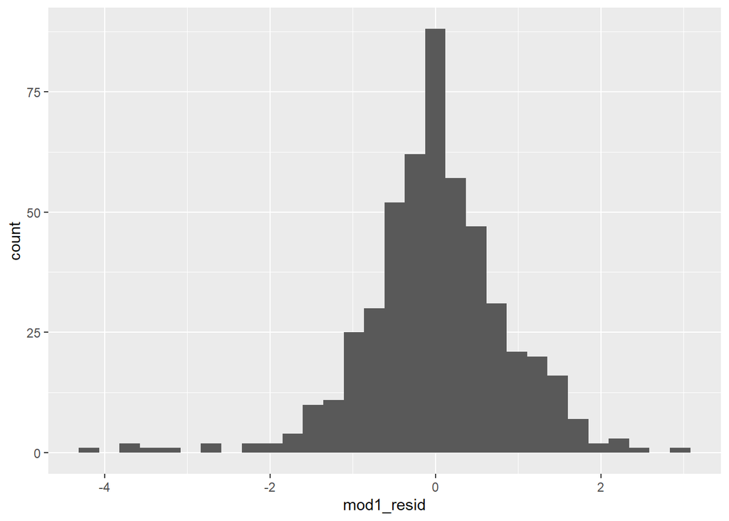

```r
fb_data_mod %>%
  mutate(
    mod1_predict = predict(model1),
    mod1_resid = resid(model1)
  ) %>%
  ggplot(aes(x=mod1_resid)) + geom_histogram()
```

[figure not shown]

[output not shown]

```r
fb_data_mod %>%
  mutate(
    mod1_predict = predict(model1),
    mod1_resid = resid(model1)
  ) %>%
  ggplot(aes(sample=mod1_resid)) + stat_qq() + stat_qq_line()
```

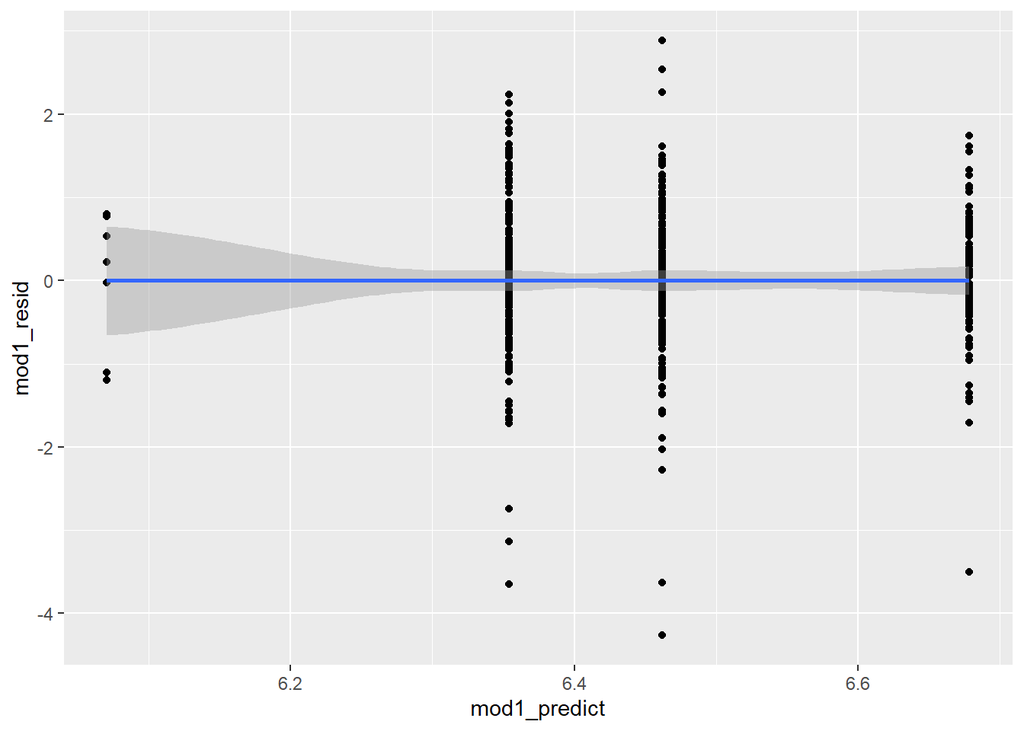

```r
fb_data_mod %>%
  mutate(
    mod1_predict = predict(model1),
    mod1_resid = resid(model1)
  ) %>%
  ggplot(aes(x=mod1_predict, y=mod1_resid)) + geom_point() + geom_smooth()
```

```r
library(lmtest)
bptest(model1)
```

```
##
##  studentized Breusch-Pagan test
##
## data:  model1
## BP = 2.1201, df = 3, p-value = 0.5479
```

### Adding Month and Weekday

We can now run another model that includes the time of the day and month as factors. This mainly to control for how the people may behave in different times of the year. These variables will be included as factors, as their interpretation is not metric:

```r
model2 = lm(I(log(lifetime_engaged_users)) ~ 1 +
                           day_period + factor(post_month) + factor(post_wkday)
                         , data=fb_data_mod)
coeftest(model2, vcov=vcovHC(model2, type="HC1"))
```

```
##
## t test of coefficients:
##
##                        Estimate Std. Error t value  Pr(>|t|)
## (Intercept)           6.8074817  0.2025591 33.6074 < 2.2e-16 ***
## day_periodevening    -0.3704396  0.2786446 -1.3294  0.184339
## day_periodmorning    -0.1416694  0.1029006 -1.3768  0.169231
## day_periodovernight  -0.0801861  0.1000394 -0.8015  0.423214
## factor(post_month)2   0.4317222  0.2037947  2.1184  0.034655 *
## factor(post_month)3  -0.5929372  0.3099125 -1.9132  0.056314 .
## factor(post_month)4  -0.1105957  0.1976462 -0.5596  0.576039
## factor(post_month)5  -0.1311496  0.1987533 -0.6599  0.509661
## factor(post_month)6   0.0154363  0.2003635  0.0770  0.938623
## factor(post_month)7  -0.0219155  0.2109065 -0.1039  0.917283
## factor(post_month)8  -0.2316077  0.2155889 -1.0743  0.283229
## factor(post_month)9  -0.1840321  0.2207179 -0.8338  0.404817
## factor(post_month)10 -0.5216397  0.2249174 -2.3193  0.020802 *
## factor(post_month)11 -0.7087772  0.2196325 -3.2271  0.001336 **
## factor(post_month)12 -0.5841190  0.2518508 -2.3193  0.020799 *
## factor(post_wkday)2  -0.0496334  0.1329705 -0.3733  0.709116
## factor(post_wkday)3   0.0932788  0.1614655  0.5777  0.563738
## factor(post_wkday)4   0.0397210  0.1274199  0.3117  0.755379
## factor(post_wkday)5  -0.0021098  0.1468698 -0.0144  0.988545
## factor(post_wkday)6  -0.0047520  0.1272268 -0.0374  0.970221
## factor(post_wkday)7  -0.0620346  0.1403812 -0.4419  0.658761
## ---
## Signif. codes:  0 '***' 0.001 '**' 0.01 '*' 0.05 '.' 0.1 ' ' 1
```

Hmmm…doing so makes our variables not significant, which may be a problem.

Let’s try to add only wkday first:

```r
model3 = lm(I(log(lifetime_engaged_users)) ~ 1 +
                           day_period + factor(post_wkday)
                         , data=fb_data_mod)
coeftest(model3, vcov=vcovHC(model3, type="HC1"))
```

```
##
## t test of coefficients:
##
##                       Estimate Std. Error t value Pr(>|t|)
## (Intercept)          6.6707937  0.1188343 56.1352  < 2e-16 ***
## day_periodevening   -0.5931207  0.2944432 -2.0144  0.04452 *
## day_periodmorning   -0.3272034  0.0996608 -3.2832  0.00110 **
## day_periodovernight -0.2203016  0.0977274 -2.2542  0.02462 *
## factor(post_wkday)2 -0.0052138  0.1346480 -0.0387  0.96913
## factor(post_wkday)3  0.1283783  0.1700679  0.7549  0.45069
## factor(post_wkday)4  0.0919454  0.1326342  0.6932  0.48850
## factor(post_wkday)5  0.0269090  0.1538448  0.1749  0.86122
## factor(post_wkday)6 -0.0160087  0.1377087 -0.1163  0.90750
## factor(post_wkday)7 -0.1206616  0.1474601 -0.8183  0.41360
## ---
## Signif. codes:  0 '***' 0.001 '**' 0.01 '*' 0.05 '.' 0.1 ' ' 1
```

Seems like weekday doesn’t add a lot of context, none of the coefficients are significant. Running an F-test reveals the same:

```r
waldtest(model1, model3, vcov=vcovHC(model3, type="HC1"))
```

```
## Wald test
##
## Model 1: I(log(lifetime_engaged_users)) ~ 1 + day_period
## Model 2: I(log(lifetime_engaged_users)) ~ 1 + day_period + factor(post_wkday)
##   Res.Df Df      F Pr(>F)
## 1    495
## 2    489  6 0.5424  0.776
```

Let’s see month:

```r
model4 = lm(I(log(lifetime_engaged_users)) ~ 1 +
                           day_period + factor(post_month)
                         , data=fb_data_mod)
coeftest(model4, vcov=vcovHC(model4, type="HC1"))
```

```
##
## t test of coefficients:
##
##                        Estimate Std. Error t value  Pr(>|t|)
## (Intercept)           6.7983371  0.1911346 35.5683 < 2.2e-16 ***
## day_periodevening    -0.3759338  0.2826026 -1.3303  0.184060
## day_periodmorning    -0.1341471  0.1013301 -1.3239  0.186174
## day_periodovernight  -0.0739811  0.1000135 -0.7397  0.459834
## factor(post_month)2   0.4481474  0.1992435  2.2492  0.024946 *
## factor(post_month)3  -0.5930903  0.3061927 -1.9370  0.053329 .
## factor(post_month)4  -0.1015517  0.1939887 -0.5235  0.600871
## factor(post_month)5  -0.1277541  0.1959260 -0.6521  0.514676
## factor(post_month)6   0.0195228  0.1949307  0.1002  0.920265
## factor(post_month)7  -0.0086607  0.2094038 -0.0414  0.967027
## factor(post_month)8  -0.2295926  0.2126163 -1.0798  0.280749
## factor(post_month)9  -0.1848269  0.2165953 -0.8533  0.393900
## factor(post_month)10 -0.5303500  0.2237131 -2.3707  0.018147 *
## factor(post_month)11 -0.7028634  0.2176614 -3.2292  0.001326 **
## factor(post_month)12 -0.5807446  0.2488175 -2.3340  0.020003 *
## ---
## Signif. codes:  0 '***' 0.001 '**' 0.01 '*' 0.05 '.' 0.1 ' ' 1
```

Ok, so month is the variable introducing all these changes. An F-test indicates that the model is appropriate. Should we include `month` in the analysis then?

```r
waldtest(model1, model4, vcov=vcovHC(model4, type="HC1"))
```

```
## Wald test
##
## Model 1: I(log(lifetime_engaged_users)) ~ 1 + day_period
## Model 2: I(log(lifetime_engaged_users)) ~ 1 + day_period + factor(post_month)
##   Res.Df Df      F    Pr(>F)
## 1    495
## 2    484 11 8.3275 1.841e-13 ***
## ---
## Signif. codes:  0 '***' 0.001 '**' 0.01 '*' 0.05 '.' 0.1 ' ' 1
```

### Adding Paid, Type and Category

Now we want to add paid, type and category:

```r
model5 = lm(I(log(lifetime_engaged_users)) ~ 1 +
                           day_period + paid + factor(category) + type
                         , data=fb_data_mod)
coeftest(model5, vcov=vcovHC(model5, type="HC1"))
```

```
##
## t test of coefficients:
##
##                      Estimate Std. Error t value  Pr(>|t|)
## (Intercept)          5.581226   0.245380 22.7452 < 2.2e-16 ***
## day_periodevening   -0.527654   0.286548 -1.8414  0.066166 .
## day_periodmorning   -0.363628   0.091495 -3.9743 8.123e-05 ***
## day_periodovernight -0.241270   0.095380 -2.5296  0.011733 *
## paid                 0.223596   0.079874  2.7994  0.005323 **
## factor(category)2    0.048718   0.099095  0.4916  0.623200
## factor(category)3    0.147781   0.086619  1.7061  0.088624 .
## typePhoto            0.942802   0.233223  4.0425 6.142e-05 ***
## typeStatus           1.910650   0.278926  6.8500 2.227e-11 ***
## typeVideo            1.775210   0.355455  4.9942 8.236e-07 ***
## ---
## Signif. codes:  0 '***' 0.001 '**' 0.01 '*' 0.05 '.' 0.1 ' ' 1
```

Run an F-test to see if the model is worth it and it is to the 0.05 level:

```r
waldtest(model1, model5, vcov=vcovHC(model5, type="HC1"))
```

```
## Wald test
##
## Model 1: I(log(lifetime_engaged_users)) ~ 1 + day_period
## Model 2: I(log(lifetime_engaged_users)) ~ 1 + day_period + paid + factor(category) +
##     type
##   Res.Df Df      F    Pr(>F)
## 1    495
## 2    489  6 13.117 8.705e-14 ***
## ---
## Signif. codes:  0 '***' 0.001 '**' 0.01 '*' 0.05 '.' 0.1 ' ' 1
```

### Summary so far

Take into account this table doesn’t have robust SEs:

```r
stargazer(
  model1, model2, model3, model4, model5,
  type="text"
)
```

```
##
## ======================================================================================================================================
##                                                                     Dependent variable:
##                      -----------------------------------------------------------------------------------------------------------------
##                                                               I(log(lifetime_engaged_users))
##                               (1)                    (2)                   (3)                   (4)                     (5)
## --------------------------------------------------------------------------------------------------------------------------------------
## day_periodevening           -0.608*                -0.370                -0.593*               -0.376                  -0.528*
##                             (0.344)                (0.338)               (0.347)               (0.334)                 (0.313)
##
## day_periodmorning          -0.325***               -0.142               -0.327***              -0.134                 -0.364***
##                             (0.107)                (0.113)               (0.108)               (0.112)                 (0.098)
##
## day_periodovernight        -0.217**                -0.080               -0.220**               -0.074                 -0.241**
##                             (0.107)                (0.110)               (0.107)               (0.109)                 (0.099)
##
## factor(post_month)2                                0.432*                                      0.448*
##                                                    (0.243)                                     (0.241)
##
## factor(post_month)3                               -0.593***                                   -0.593***
##                                                    (0.229)                                     (0.227)
##
## factor(post_month)4                                -0.111                                      -0.102
##                                                    (0.212)                                     (0.210)
##
## factor(post_month)5                                -0.131                                      -0.128
##                                                    (0.222)                                     (0.221)
##
## factor(post_month)6                                 0.015                                       0.020
##                                                    (0.212)                                     (0.210)
##
## factor(post_month)7                                -0.022                                      -0.009
##                                                    (0.209)                                     (0.208)
##
## factor(post_month)8                                -0.232                                      -0.230
##                                                    (0.225)                                     (0.224)
##
## factor(post_month)9                                -0.184                                      -0.185
##                                                    (0.224)                                     (0.222)
##
```

[output cut: 41 more lines]

```
##
## typeVideo                                                                                                             1.775***
##                                                                                                                        (0.348)
##
## Constant                   6.679***               6.807***              6.671***              6.798***                5.581***
##                             (0.086)                (0.216)               (0.132)               (0.193)                 (0.190)
##
## --------------------------------------------------------------------------------------------------------------------------------------
## Observations                  499                    499                   499                   499                     499
## R2                           0.021                  0.135                 0.028                 0.132                   0.205
## Adjusted R2                  0.015                  0.099                 0.010                 0.107                   0.191
## Residual Std. Error    0.881 (df = 495)       0.843 (df = 478)      0.883 (df = 489)      0.839 (df = 484)        0.799 (df = 489)
## F Statistic          3.519** (df = 3; 495) 3.729*** (df = 20; 478) 1.576 (df = 9; 489) 5.262*** (df = 14; 484) 14.027*** (df = 9; 489)
## ======================================================================================================================================
## Note:                                                                                                      *p<0.1; **p<0.05; ***p<0.01
```

One issue we have with this is that we have a very low R2 (~10%). We need another variable that can explain this better.

### Add Brand Awareness

```r
model6 = lm(I(log(lifetime_engaged_users)) ~ 1 +
                           day_period +
                           paid + factor(category) + type +
                           page_ttl_likes
                         , data=fb_data_mod)
coeftest(model6, vcov=vcovHC(model6, type="HC1"))
```

```
##
## t test of coefficients:
##
##                        Estimate  Std. Error t value  Pr(>|t|)
## (Intercept)          7.1746e+00  3.8475e-01 18.6472 < 2.2e-16 ***
## day_periodevening   -5.7936e-01  3.1821e-01 -1.8207  0.069270 .
## day_periodmorning   -1.8896e-01  9.2618e-02 -2.0402  0.041869 *
## day_periodovernight -9.6366e-02  9.6759e-02 -0.9959  0.319775
## paid                 2.2385e-01  7.7881e-02  2.8743  0.004227 **
## factor(category)2    8.8406e-02  9.5323e-02  0.9274  0.354162
## factor(category)3    8.1076e-02  8.5705e-02  0.9460  0.344624
## typePhoto            1.0684e+00  2.3695e-01  4.5089 8.170e-06 ***
## typeStatus           2.1229e+00  2.8132e-01  7.5464 2.211e-13 ***
## typeVideo            2.0517e+00  3.4693e-01  5.9140 6.284e-09 ***
## page_ttl_likes      -1.4896e-05  2.5054e-06 -5.9456 5.252e-09 ***
## ---
## Signif. codes:  0 '***' 0.001 '**' 0.01 '*' 0.05 '.' 0.1 ' ' 1
```

```r
waldtest(model5, model6, vcov=vcovHC(model6, type="HC1"))
```

```
## Wald test
##
## Model 1: I(log(lifetime_engaged_users)) ~ 1 + day_period + paid + factor(category) +
##     type
## Model 2: I(log(lifetime_engaged_users)) ~ 1 + day_period + paid + factor(category) +
##     type + page_ttl_likes
##   Res.Df Df     F    Pr(>F)
## 1    489
## 2    488  1 35.35 5.252e-09 ***
## ---
## Signif. codes:  0 '***' 0.001 '**' 0.01 '*' 0.05 '.' 0.1 ' ' 1
```

The R2 improves significantly, but it is still low (~25%):

```r
summary(model6)
```

```
##
## Call:
## lm(formula = I(log(lifetime_engaged_users)) ~ 1 + day_period +
##     paid + factor(category) + type + page_ttl_likes, data = fb_data_mod)
##
## Residuals:
##     Min      1Q  Median      3Q     Max
## -4.7105 -0.3556  0.0026  0.4026  2.4856
##
## Coefficients:
##                       Estimate Std. Error t value Pr(>|t|)
## (Intercept)          7.175e+00  3.084e-01  23.260  < 2e-16 ***
## day_periodevening   -5.794e-01  3.007e-01  -1.926  0.05463 .
## day_periodmorning   -1.890e-01  9.804e-02  -1.927  0.05452 .
## day_periodovernight -9.637e-02  9.778e-02  -0.985  0.32487
## paid                 2.239e-01  7.735e-02   2.894  0.00397 **
## factor(category)2    8.841e-02  9.670e-02   0.914  0.36103
## factor(category)3    8.108e-02  8.456e-02   0.959  0.33813
## typePhoto            1.068e+00  1.742e-01   6.133 1.78e-09 ***
## typeStatus           2.123e+00  2.183e-01   9.727  < 2e-16 ***
## typeVideo            2.052e+00  3.377e-01   6.075 2.49e-09 ***
## page_ttl_likes      -1.490e-05  2.325e-06  -6.407 3.49e-10 ***
## ---
## Signif. codes:  0 '***' 0.001 '**' 0.01 '*' 0.05 '.' 0.1 ' ' 1
##
## Residual standard error: 0.768 on 488 degrees of freedom
## Multiple R-squared:  0.2669, Adjusted R-squared:  0.2518
## F-statistic: 17.76 on 10 and 488 DF,  p-value: < 2.2e-16
```

### Include ALL

One last test including all the variables we discussed:

```r
model_all = lm(I(log(lifetime_engaged_users)) ~ 1 +
                           day_period +
                           factor(post_month) + factor(post_wkday) +
                           paid + factor(category) + type +
                           page_ttl_likes
                         , data=fb_data_mod)
coeftest(model_all, vcov=vcovHC(model_all, type="HC1"))
```

```
##
## t test of coefficients:
##
##                         Estimate  Std. Error t value  Pr(>|t|)
## (Intercept)           7.9877e+00  2.1829e+00  3.6593 0.0002815 ***
## day_periodevening    -3.4510e-01  2.6727e-01 -1.2912 0.1972653
## day_periodmorning    -1.3658e-01  9.6664e-02 -1.4130 0.1583211
## day_periodovernight  -5.0810e-02  9.4132e-02 -0.5398 0.5896126
## factor(post_month)2   4.2079e-01  2.4122e-01  1.7444 0.0817340 .
## factor(post_month)3  -4.2071e-01  4.9902e-01 -0.8431 0.3996186
## factor(post_month)4   2.6586e-01  6.5454e-01  0.4062 0.6847994
## factor(post_month)5   3.6665e-01  8.4739e-01  0.4327 0.6654432
## factor(post_month)6   6.3651e-01  1.0151e+00  0.6271 0.5309226
## factor(post_month)7   5.9969e-01  1.1216e+00  0.5347 0.5931409
## factor(post_month)8   5.0308e-01  1.2208e+00  0.4121 0.6804728
## factor(post_month)9   5.8518e-01  1.2819e+00  0.4565 0.6482402
## factor(post_month)10  3.3697e-01  1.3100e+00  0.2572 0.7971077
## factor(post_month)11  1.2379e-01  1.3375e+00  0.0925 0.9263022
## factor(post_month)12  2.7220e-01  1.3883e+00  0.1961 0.8446436
## factor(post_wkday)2  -6.4815e-02  1.2827e-01 -0.5053 0.6135762
## factor(post_wkday)3  -2.8368e-02  1.3552e-01 -0.2093 0.8342815
## factor(post_wkday)4  -1.5429e-03  1.2021e-01 -0.0128 0.9897646
## factor(post_wkday)5  -1.0917e-01  1.3065e-01 -0.8356 0.4038199
## factor(post_wkday)6  -7.1673e-02  1.0970e-01 -0.6534 0.5138485
## factor(post_wkday)7  -1.3720e-01  1.1931e-01 -1.1500 0.2507238
## paid                  1.8319e-01  8.1471e-02  2.2486 0.0250010 *
## factor(category)2    -6.6945e-02  9.5933e-02 -0.6978 0.4856249
## factor(category)3    -6.3261e-02  7.8494e-02 -0.8059 0.4206836
## typePhoto             1.0005e+00  2.2643e-01  4.4187 1.233e-05 ***
## typeStatus            2.1505e+00  2.6879e-01  8.0004 9.717e-15 ***
## typeVideo             1.9778e+00  3.0632e-01  6.4569 2.665e-10 ***
## page_ttl_likes       -2.2735e-05  2.5432e-05 -0.8940 0.3717953
## ---
## Signif. codes:  0 '***' 0.001 '**' 0.01 '*' 0.05 '.' 0.1 ' ' 1
```

```r
model_inter = lm(I(log(lifetime_engaged_users)) ~ 1 +
                           day_period +
                           paid + factor(category) + type +
                           page_ttl_likes + factor(category)*type
                         , data=fb_data_mod)
coeftest(model_inter, vcov=vcovHC(model_inter, type="HC1"))
```

```
##
## t test of coefficients:
##
##                                 Estimate  Std. Error t value  Pr(>|t|)
## (Intercept)                   7.2010e+00  4.0551e-01 17.7580 < 2.2e-16 ***
## day_periodevening            -5.7615e-01  3.1777e-01 -1.8131 0.0704317 .
## day_periodmorning            -1.7724e-01  9.3031e-02 -1.9052 0.0573523 .
## day_periodovernight          -8.9984e-02  9.6459e-02 -0.9329 0.3513540
## paid                          2.1089e-01  7.8386e-02  2.6903 0.0073846 **
## factor(category)2            -9.4189e-01  2.6465e-01 -3.5591 0.0004089 ***
## factor(category)3             3.5760e-02  2.5739e-01  0.1389 0.8895615
## typePhoto                     1.0138e+00  2.5730e-01  3.9401 9.344e-05 ***
## typeStatus                    2.0731e+00  5.4814e-01  3.7821 0.0001750 ***
## typeVideo                     2.0027e+00  3.5866e-01  5.5840 3.924e-08 ***
## page_ttl_likes               -1.4737e-05  2.5283e-06 -5.8290 1.020e-08 ***
## factor(category)2:typePhoto   1.0021e+00  2.8380e-01  3.5310 0.0004536 ***
## factor(category)3:typePhoto   7.7536e-02  2.6327e-01  0.2945 0.7684961
## factor(category)2:typeStatus  1.1287e+00  5.8162e-01  1.9406 0.0528906 .
## factor(category)3:typeStatus -9.2281e-01  8.4426e-01 -1.0930 0.2749209
## ---
## Signif. codes:  0 '***' 0.001 '**' 0.01 '*' 0.05 '.' 0.1 ' ' 1
```

```r
waldtest(model5, model_inter, vcov=vcovHC(model_inter, type="HC1"))
```

```
## Wald test
##
## Model 1: I(log(lifetime_engaged_users)) ~ 1 + day_period + paid + factor(category) +
##     type
## Model 2: I(log(lifetime_engaged_users)) ~ 1 + day_period + paid + factor(category) +
##     type + page_ttl_likes + factor(category) * type
##   Res.Df Df      F    Pr(>F)
## 1    489
## 2    484  5 17.849 2.968e-16 ***
## ---
## Signif. codes:  0 '***' 0.001 '**' 0.01 '*' 0.05 '.' 0.1 ' ' 1
```